# Compiler tutorial: LBDP from table to filter

PhyloPOMP.jl, 2026-10-07

## Run this now

```bash
quarto render docs/tutorial/compiler_tutorial.qmd
```

Run it from the PhyloPOMP.jl directory. It writes `docs/tutorial/compiler_tutorial.html`. It uses the same environment as the simulator tutorial.

## Setup

```julia
import Pkg
Pkg.activate(joinpath(@__DIR__, "simulator"))
Pkg.instantiate()

using PhyloPOMP
using PhyloPOMP: full_transitions, reduce_event_indicator, total_decay, validate_model
using Random: Xoshiro, seed!
import CairoMakie
```

```
  Activating project at `~/Desktop/Projects/PhyloPOMP.jl/docs/tutorial/simulator`
Precompiling packages...
   9.0 s  ✓ PhyloPOMP
   6.7 s  ✓ PhyloPOMP → PhyloPOMPMakieExt
  2 dependencies successfully precompiled in 17 seconds. 495 already precompiled.
```

## 1. The model is a table

LBDP is the linear birth-death-sampling process. One compartment, `n`, the number of infected hosts. Every rate is per host.

```julia
θ  = (λ = 1.5, μ = 0.5, ψ = 0.3, χ = 0.2)
x0 = (n = 1,)

for ev in LBDP.events
    println(rpad(string(ev.name), 16), rpad(string(ev.type), 8),
            " Δ = ", ev.Δ, "  r = ", ev.r, "  rate now = ", ev.hazard(x0, θ))
end
println("problems found: ", validate_model(LBDP))
```

```
birth           BIRTH    Δ = [:n => 1]  r = [2]  rate now = 1.5
death           DEATH    Δ = [:n => -1]  r = [0]  rate now = 0.5
sampling        SAMPLE   Δ = Pair{Symbol, Int64}[]  r = [1]  rate now = 0.3
sampling_remove SAMPLE   Δ = [:n => -1]  r = [0]  rate now = 0.2
problems found: String[]
```

| Event | What happens to the tree |
| --- | --- |
| `birth` | A branch point: one lineage becomes two. |
| `death` | A lineage ends without a sample. |
| `sampling` | A sample; the host stays infected (`ψ`). |
| `sampling_remove` | A sample that removes the host (`χ`). |

## 2. Simulate a genealogy from the table

Keep the first tree with 5 to 10 samples, so that it has several branch points.

```
samples: 6, branch points: 3
```

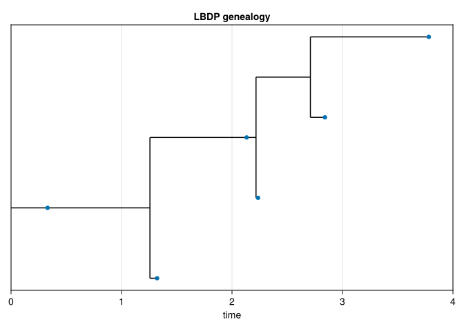

```julia
rng = Xoshiro(12)
g = simulate(LBDP, θ; x0 = x0, graft = [1], tmax = 4.0, rng = rng)
while !(5 <= nsample(g) <= 10)
    global g = simulate(LBDP, θ; x0 = x0, graft = [1], tmax = 4.0, rng = rng)
end
println("samples: ", nsample(g), ", branch points: ", length(nodes(g)))
genealogyplot(g, title = "LBDP genealogy")
```

## 3. What the compiler derives from one event

The filter tracks `ℓ`, the number of lineages of the tree alive at time `t`. A birth among `n` hosts may or may not join two of them. `full_transitions` lists every case with its compatibility factor `φ`.

```julia
birth = LBDP.events[1]
ℓ, n = [2], [5]          # 2 tracked lineages, 5 hosts after the birth
for t in full_transitions(birth, ℓ, n)
    println(rpad(string(typeof(t)), 28), " s = ", t.s, "  φ = ", t.phi)
end
```

```
PhyloPOMP.IdentityTransition s = [0]  φ = 3//10
PhyloPOMP.InlineSameDemeTransition s = [1]  φ = 3//10
PhyloPOMP.ForkTransition     s = [2]  φ = 1//10
```

- `IdentityTransition`: the birth involved no tracked lineage.
- `InlineSameDemeTransition`: it involved one tracked lineage, which stays where it was.
- `ForkTransition`: it joined two tracked lineages. That is a branch point of the tree.

Each `φ` is for one configuration of the class. `InlineSameDemeTransition` stands for `ℓ` configurations (any of the `ℓ` tracked lineages can be the parent’s), and the fork for `C(ℓ,2)`. Weighted by these counts, the outcomes are probabilities and sum to 1. `reduced_transitions` reports both: `Φ`, the plain sum of `φ`, and `mass`, the weighted sum.

```julia
for r in PhyloPOMP.reduced_transitions(birth, ℓ, n)
    println(rpad(string(r.kind), 6), " Φ = ", r.Φ, "   mass = ", r.mass)
end
ts = full_transitions(birth, ℓ, n)
Φid  = only(t.phi for t in ts if t isa PhyloPOMP.IdentityTransition)
Φinl = only(t.phi for t in ts if t isa PhyloPOMP.InlineSameDemeTransition)
println("Φ_id + ℓ·Φ_inl   = ", Φid + ℓ[1] * Φinl)
println("1 - C(2,2)/C(5,2) = ", 1 - 1//10)
```

```
noop   Φ = 3//5   mass = 9//10
fork   Φ = 1//10   mass = 1//10
Φ_id + ℓ·Φ_inl   = 9//10
1 - C(2,2)/C(5,2) = 9//10
```

Between tree nodes no branch point is visible, so the filter weights a birth by the no-fork mass, `Φ_id + ℓ·Φ_inl = 1 − C(ℓ,2)/C(n,2)`, not by the plain sum `Φ`.

The decay term is the rate of events the tree rules out between nodes. For LBDP it is the sampling rate `(ψ + χ)·n`, plus deaths when every host is tracked:

```julia
println("decay at n = 5, ℓ = 2: ", total_decay(LBDP, (n = 5,), θ, [2], [5]))
println("decay at n = 2, ℓ = 2: ", total_decay(LBDP, (n = 2,), θ, [2], [2]))
```

```
decay at n = 5, ℓ = 2: 2.5
decay at n = 2, ℓ = 2: 2.0
```

## 4. The generated filter

`mgp_filter_pomp` assembles the singular step (at each tree node) and the regular step (between nodes) into a pomp object. Nothing in it is specific to LBDP.

```julia
P = mgp_filter_pomp(g, LBDP; θ = θ, x0 = x0)
seed!(1)
ll = [logLik(pfilter(P, Np = 2000)) for _ in 1:20]
est, se = logmeanexp(ll, se = true)
println("filter estimate: ", round(est, digits = 3), " ± ", round(se, digits = 3))
```

```
filter estimate: -9.058 ± 0.02
```

## 5. Check against the exact likelihood

For LBDP the likelihood of a genealogy has a closed form (`lbdp_exact`, ported from R phylopomp). The filter is a Monte Carlo estimate of the same number.

```julia
exact = lbdp_exact(g; θ...)
println("exact:           ", round(exact, digits = 3))
println("filter - exact:  ", round(est - exact, digits = 3),
        "  (", round((est - exact) / se, digits = 2), " standard errors)")
```

```
exact:           -9.039
filter - exact:  -0.02  (-1.0 standard errors)
```

A difference of a few standard errors or less is what a correct filter gives. One tree is one check. The next cell repeats it on 8 more trees with 3 to 12 samples. On the natural scale an unbiased filter gives a mean of `exp(ll - exact)` equal to 1.

```julia
seed!(2)
for k in 1:8
    h = simulate(LBDP, θ; x0 = x0, graft = [1], tmax = 4.0, rng = rng)
    while !(3 <= nsample(h) <= 12)
        h = simulate(LBDP, θ; x0 = x0, graft = [1], tmax = 4.0, rng = rng)
    end
    ex = lbdp_exact(h; θ...)
    w = [exp(logLik(pfilter(mgp_filter_pomp(h, LBDP; θ = θ, x0 = x0), Np = 1000)) - ex) for _ in 1:20]
    m = sum(w) / 20; se = sqrt(sum((w .- m) .^ 2) / 19 / 20)
    println("tree $k: ", lpad(nsample(h), 2), " samples   mean exp(ll - exact) = ",
            round(m, digits = 3), " ± ", round(se, digits = 3))
end
```

```
tree 1:  8 samples   mean exp(ll - exact) = 1.156 ± 0.147
tree 2:  3 samples   mean exp(ll - exact) = 1.019 ± 0.018
tree 3: 12 samples   mean exp(ll - exact) = 1.031 ± 0.026
tree 4:  9 samples   mean exp(ll - exact) = 1.064 ± 0.08
tree 5:  5 samples   mean exp(ll - exact) = 1.085 ± 0.072
tree 6: 10 samples   mean exp(ll - exact) = 1.002 ± 0.021
tree 7: 11 samples   mean exp(ll - exact) = 0.962 ± 0.031
tree 8:  7 samples   mean exp(ll - exact) = 1.041 ± 0.038
```

`test/mgp_filter_pomp_test.jl` runs the check on two trees simulated by R, and `test/exact_likelihood_test.jl` on SEIR, against an exact likelihood computed host by host.

## 6. A likelihood profile

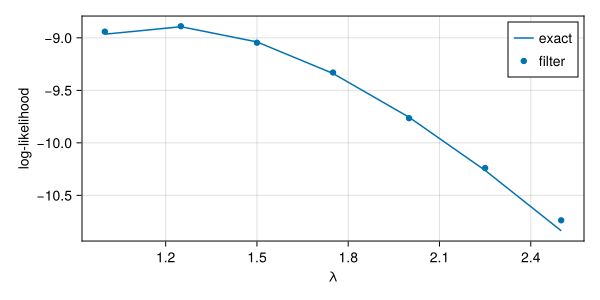

```julia
λs = 1.0:0.25:2.5
ex = [lbdp_exact(g; θ..., λ = λ) for λ in λs]
fi = map(λs) do λ
    Pλ = mgp_filter_pomp(g, LBDP; θ = merge(θ, (λ = λ,)), x0 = x0)
    logmeanexp([logLik(pfilter(Pλ, Np = 1000)) for _ in 1:10])
end
fig = CairoMakie.Figure(size = (600, 300))
ax = CairoMakie.Axis(fig[1, 1], xlabel = "λ", ylabel = "log-likelihood")
CairoMakie.lines!(ax, collect(λs), ex, label = "exact")
CairoMakie.scatter!(ax, collect(λs), fi, label = "filter")
CairoMakie.axislegend(ax)
fig
```